# RaceReport

## Fantasy League Scores

Scores for drivers/constructors in the current year's fantasy league, along with manager/team points, values, and statistics. Note: driver and constructor values are taken as the cost to enter the current race and are updated the week before the race.

## Lineup Scores

This week, Grand Prix winner Oscar Piastri takes the top score ahead of his teammate Lando Norris in total McLaren dominance. Oscar comes home with a whopping 58 points with Lando just 3 behind with 55. These two are leaps ahead of Yuki Tsunoda, who finally decided to show up, with 33 points. Close behind is Lewis Hamilton with 32, and George Russel rounds out the top five with 30 points. Jack Doohan rounds out a disappointing opening to his F1 career with -14 points, along with Liam Lawson at the bottom of the grid. They're closely followed by Fernando Alonso who returns to his form this year with -13 points. In third, we have Gabriel Bortoleto who loses 11 points, followed by Charles Leclerc with -8 points. Oliver Bearman rounds out the bottom five with -4 points.

It's no surprise that McLaren top the weekly table in Miami, bringing home over double the points of their nearest rivals with 118 points. Red Bull are in second with 60 points and Mercedes bring it home in third place with 51. Racing Bulls suffer a negative points haul at the bottom of the table this week with -6 points. Haas are down at the slow end as well with 8 points, followed by Kick Sauber with 9 points.

Lando is still clear at the top of the standings with 250 points, but Oscar closes in a little bit more this week in second with 220 points. Max Verstappen is a distant third now with 167 points, as the two Mercedes drivers close in on him. Russell is in fourth with 155 and Antonelli in fifth with 124 points. Fernando has spent all season at the bottom of the table and continues that streak, he's now dropped back down to -33 points. Gabriel Bortoleto joins him at the bottom with -17 points, and Jack Doohan is in third place with -14 points. Carlos Sainz maintains his tally of -4 this week, and Liam Lawson rounds out the bottom five with -2 points.

McLaren naturally extend their lead at the top of the table this week, they have now amassed 539 points ahead of nearest rival, though still quite distant, Mercedes with 349 points. Red Bull round out the top three, though Ferrari aren't all that far away, with 259 points. It's a tight fight at the bottom but Kick Sauber hold on to that honour with 12 points. Alpine are in second with 15, and Aston Martin round out the bottom three with 56.

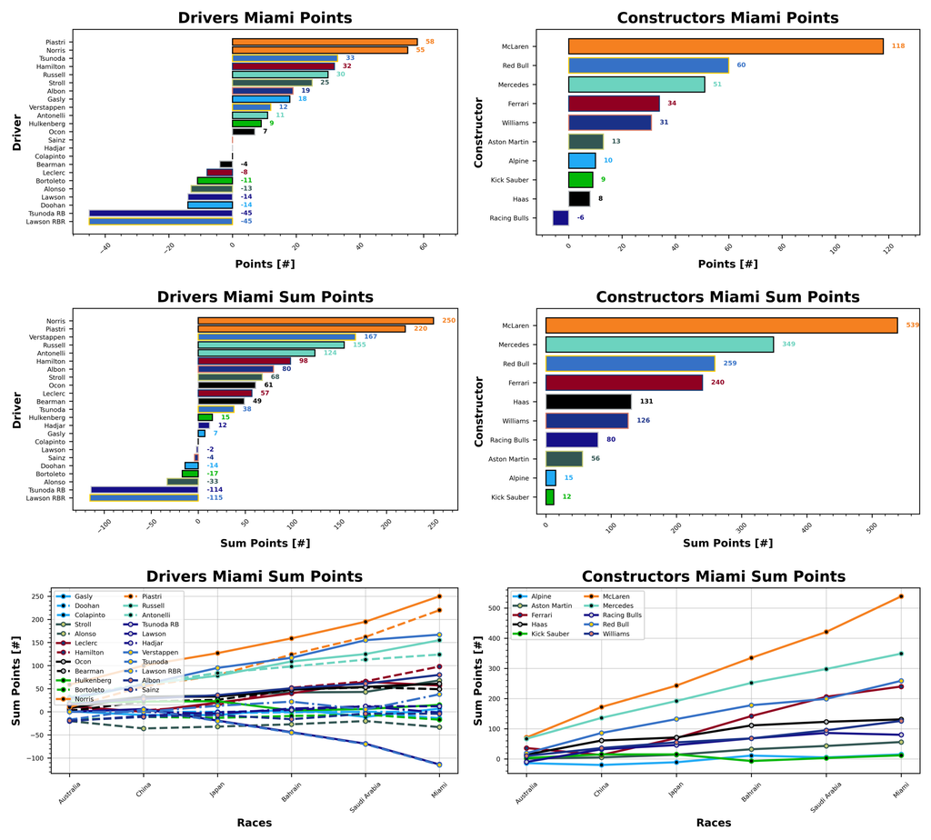

Lando Norris might be looking good in the standings, but his value of $30.1 is about to start writing cheques it can't cash, because Oscar is starting to look like good value for money, he's down in fourth with $23.7. Max Verstappen's value rises this week to $28.9 ahead of Charles Leclerc at $24.6. Lewis Hamilton rounds out the expensive five with a value of $23.3. I'm fairly certain Gabriel Bortoleto has capped out at the minimum value of $4.5, because he hasn't moved on for a while. Franco Colapinto has entered the scene too, he's dirt cheap at the moment so you might want to grab yourself a bargain. Jack Doohan is in second with a value of $5.0, behind Isack Hadjar at $5.7. Fernando Alonso continues to plummet down the order with a value of $6.1. Nico Hulkenberg and Liam Lawson's value continues to drop, the pair are now worth $6.6.

McLaren's value might now be the highest we've ever seen in this fantasy league, and once I get my legacy code sorted, I'll be able to fact check myself on that one, they now sit at $31.5 ahead of Ferrari in second with a value of $27.6 and Red Bull in third with a value of $26.3. Kick Sauber are approaching that bottom cap with a value of $4.8, behind Alpine at $8.1 and Aston Martin at $8.3.

All values are in $M.

Liam Lawson is now officially the worst driver of the season, only managing to score positively 1/3 of the time. Alonso, Bortoleto, Gasly, Sainz, and Tsunoda are averaging a 1/2 positive scoring rate. Doohan, Hadjar, and Leclerc manage it 2/3 of the time (which makes you question the Doohan decision really...). Hulkenberg, Hamilton, and Bearman have managed a positive score 5/6 weekends, with the rest of the field maintaining their 100% record as we make it 1/4 of the way through the season.

Alpine are by far the worst team of the season, managing a positive points haul 1/2 of the time. Kick Sauber, despite being bottom of the table, and Racing Bulls have managed a positive score 2/3 of the time, which tells me that Kick Sauber's negative scores have been bigger than Alpine's. Ferrari have managed a positive score at all but one of the Grand Prix weekends, with the rest of the field scoring positively at all of the races. That's only really surprising for Aston Martin. Given Alonso is at the bottom of the table with quite a large negative score, Lance Stroll must be putting in quite the performance to keep Aston positive 100% of the time. Credit where credit is due.

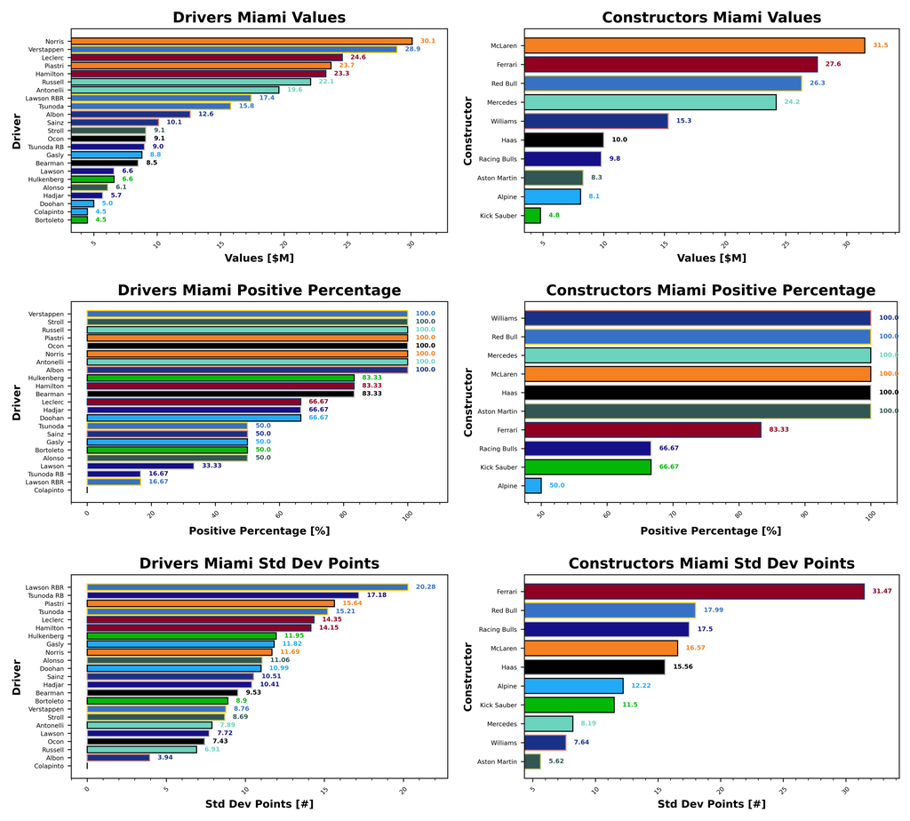

Obviously the order for the average points score will always match that of the championship standings, how could it ever differ, but the values are what is interesting here. Lando Norris is averaging 41.67 points per race at the moment, Piastri is only 36.67 points per race in second, and Verstappen is bringing in 27.83 points per race. Russel is at 25.83 and Antonelli is bringing home 20.67 points per race. Alonso is sitting on -5.5 points per race, behind Bortoleto with -2.83 points per race. Jack Doohan is scraping -2.33 points per race, while Sainz and Lawson are barely below negative with -0.67 and -0.33 points per race.

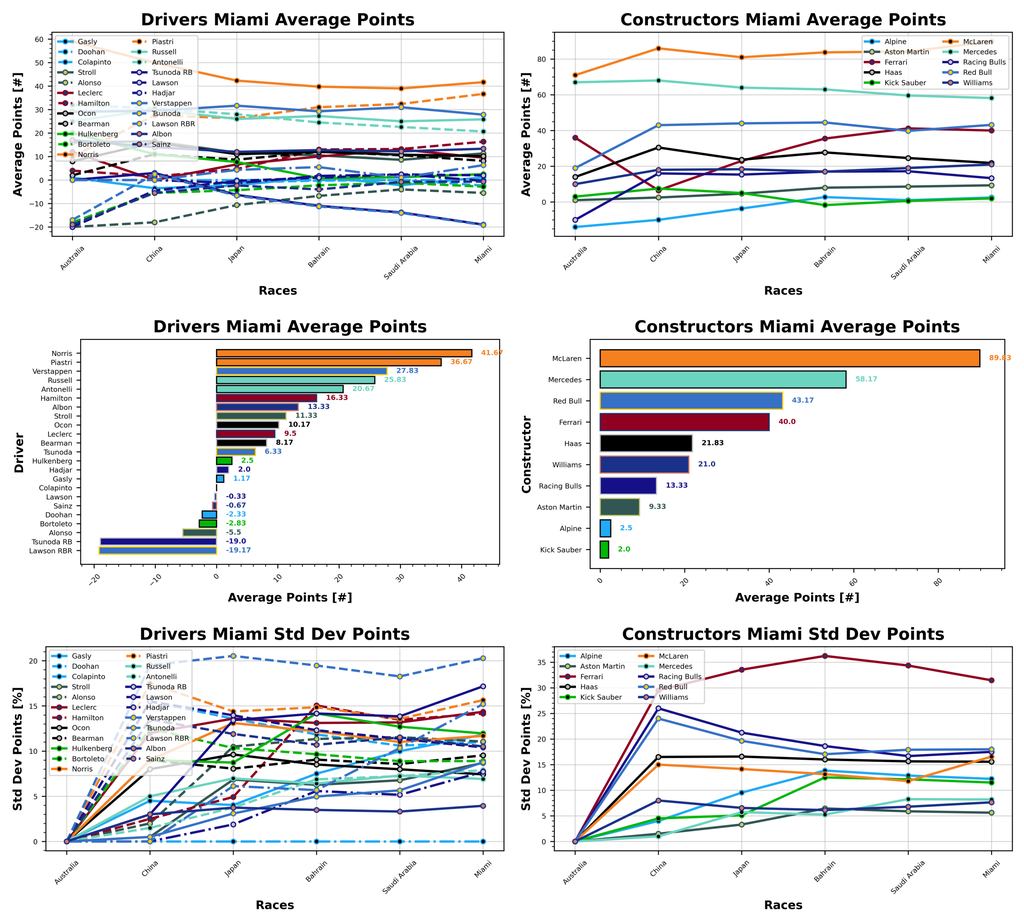

What really matters, though, is the points per value that these drivers and constructors are bringing in, because there is still something to be said for making the most of your limited cost cap. So let's take a look at that table.

Lance Stroll was your driver of the week, yep that's right, he might not be winning races, but he's scoring you 2.75 ppm. Oscar Piastri was the best of the Mclaren drivers in second, scoring 2.45 ppm. Next up is Yuki Tsunoda, beating his more accomplished teammate in third with 2.09 ppm. Pierre Gasly makes the top five, and almost the podium, scoring 2.05 ppm. Championship leader, Lando Norris, rounds out the top five this week with 1.83 ppm.

McLaren were your team of the week, again, scoring 3.75 ppm, ahead of Red Bull with 2.28 ppm, and Mercedes with 2.11 ppm. Racing Bulls were your worst team of the week, scoring -0.61 ppm. Haas were the worst of the positive scorers with 0.8 ppm, and Ferrari round out the bottom three with 1.23 ppm, tied with Alpine, ouch.

ppm = points per million ($).

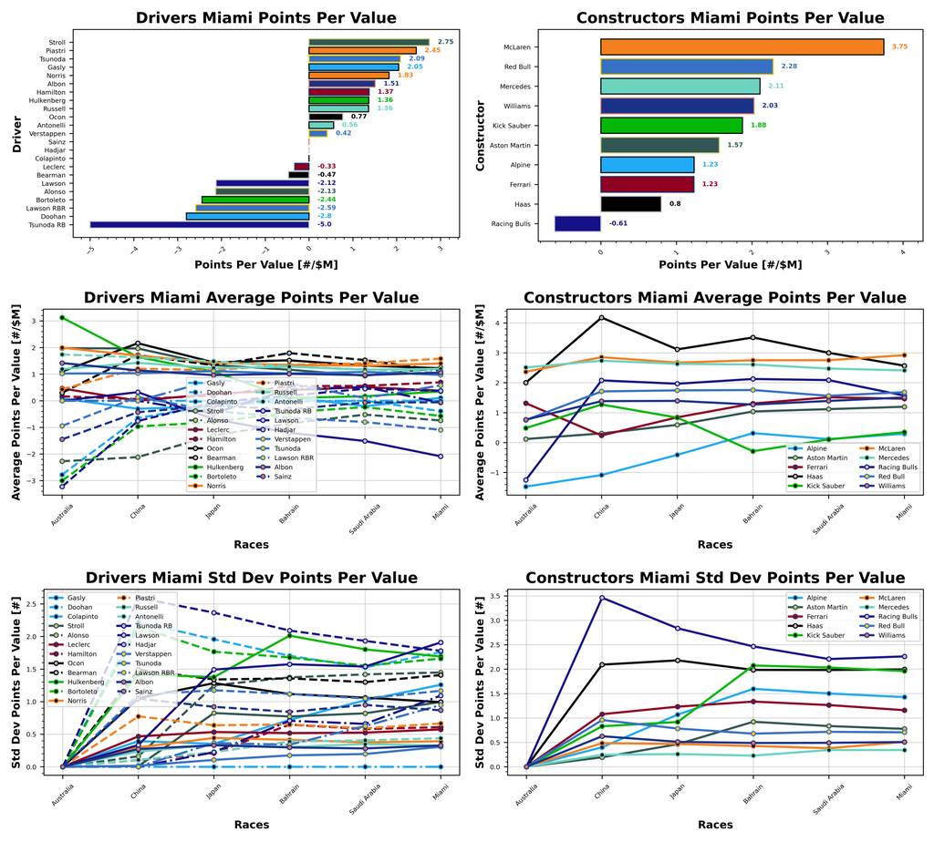

### Manager Scores

We obviously had a sprint weekend this week, which means we have some excessive token usage going on. With that in mind, it's Josh who took the top score this week with their team Expensify APX GP bringing in 390 points. Sebastian is in second with their team Bridgestone Toro Rosso F1 with 376 points, ahead of their other team BWT Racing Point F1 with 371. Reigning champion Stefanus is in fourth with Syahrul scoring 323 points, ahead of their other team Haryanto with 314 points.

Stuart took the honours at the bottom of the table with Taylormade To Lose scoring -51 points. Alfie and Cucumberpotatolamborghini are in second with -39 points. Then it's Pete with Seagiant F1 Online and -26 points. Followed by James and Bwoah Schweppes Puma Golf with -21 points. Will rounds out the bottom five with Dinoco Piston Cup Champs scoring -13 points.

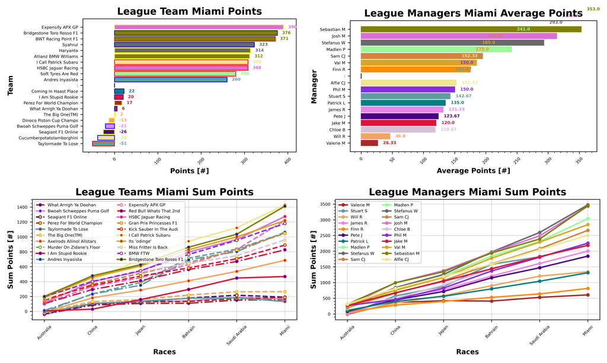

Alfie is barely holding on to the lead at the top of the table after Miami, their team I Call Patrick Subaru is now sitting on 1430 points, just ahead of Sebastian and Bridgestone Toro Rosso F1 with 1412. Josh and HSBC Jaguar Racing moves up to third place with 1274 points. Stefanus jumps up the order with Haryanto and Syahrul now rounding out the top five with 1268 and 1238 points, respectively.

Alfie makes it into negative at the bottom of the table with Cucumberpotatolamborghini, sitting sweet on -12 points. Stuart moves into second place with Taylormade To Lose and 132 points. Valerie and What Arrrgh Ya Doohan need to make some changes as they start climbing up the order with 158 points in third. Movement from the Bwoah factory as James and Bwoah Schweppes Puma Golf slides into fourth place with 168, and Valerie rounds out the bottom five with Perez For World Champion sitting on 188 points.

Our biggest winner this week was Sebastian and their team BWT Racing Point F1, jumping 10 places in the standings. Josh and Expensify APX GP move up 6 places, and Sebastian with their team Allianz BMW Williams, jump up 5 places. Our biggest loser this week, or losers, were Val, Chloe, Stuart, and Madlen with their teams Its 'odinge', Mickeys Roadster Racers, Murder On Zidane's Floor, and Wet Tyres Are Blue all slipping 4 places. There's a bunch of teams who also lost 3 places, so let's move on so I don't have to write out everyone's team names.

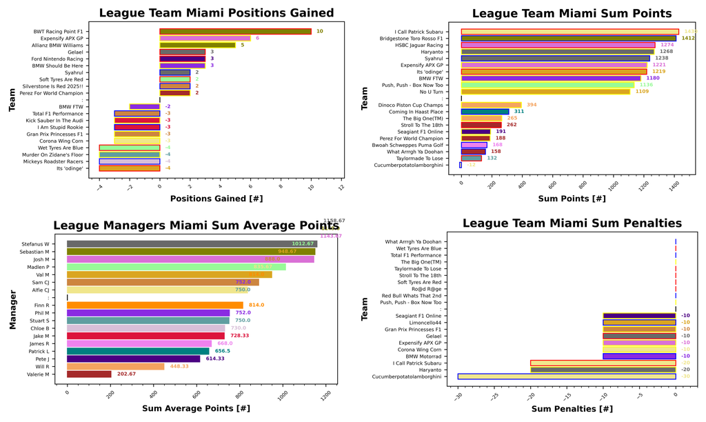

Hadjar continues to be the driver of choice, heading up to 36 selections across your teams, he's so well used my autocorrect in my coding environment is now using "is" to complete his name. Oliver Bearman is next with 25 selections, followed by Piastri with 19, Bortoleto with 16, and then Russell, Alonso, and Albon all making it into 13 teams. Lewis Hamilton is the least used driver, active anyway, with 2 selections (tied with Yuki Tsunoda). Charles Leclerc and Verstappen make 5 selections, followed by Liam Lawson with 6. Lance Stroll makes it into 7 of your teams, and Gasly and Antonelli round out the bottom five with 9 selections each.

McLaren and Haas are your favourite teams it seems with 17 counts each, followed by Mercedes and Kick Sauber with 14. Ferrari round out the top three with 9. Given all the ties, I'll just keep going. Aston Martin make it 7, Racing Bulls 6, and Williams, Red Bull, and Alpine are your least selected with 4 each.

Oscar Piastri makes 12 DRS boost selections this week, 4 more than his teammate Norris, followed by Bortoleto with 6. That might be explained by 4 of you choosing to Extra DRS boost Piastri, with 3 of you choosing Russell, Norris, and Bortoleto (1 each). We had 7 Extra DRS tokens, 5 No Negatives, and 3 Limitless tokens in use this week.

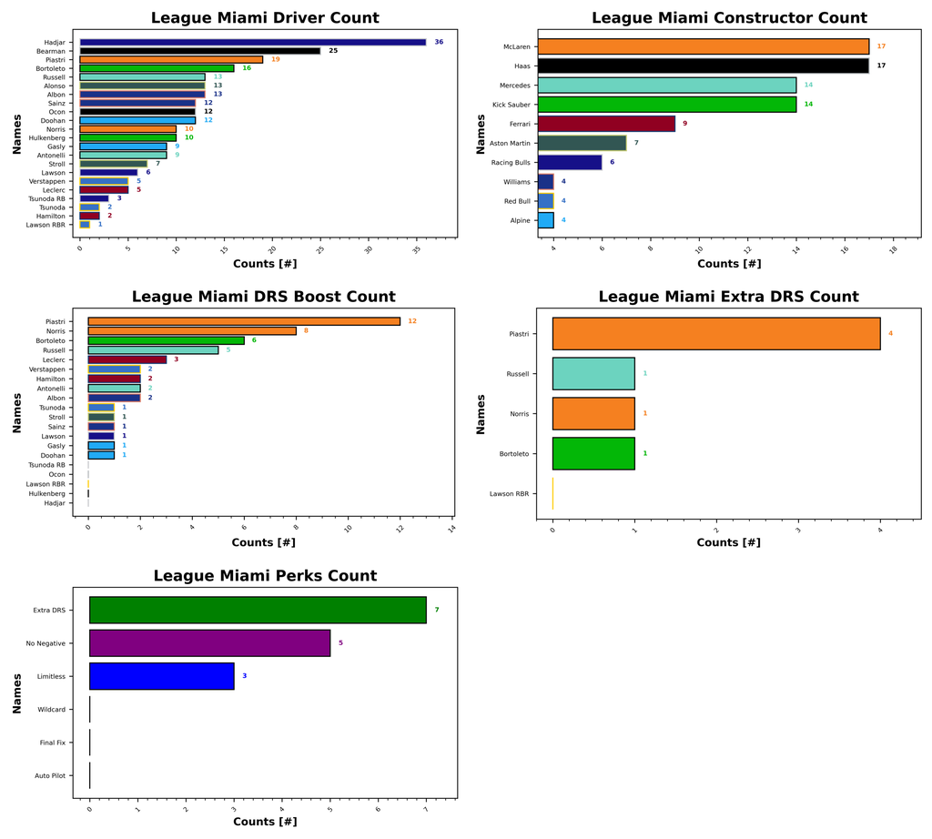

## Prizes

I have now updated the prizes plotting for my code and we should be able to track the season long prizes with ease. So without further adieu, let's take a look at what is currently in play this season.

### Championship

| Prize Name | Prize Value | Terms |
| --- | --- | --- |
|  | (%) |  |
| Champion of the World | 20 | Awarded to the top scorer in the league at the end of the season |
| If You're Not First, You're Last | 10 | Awarded to the second place scorer in the league at the end of the season |
| Alpine Podium | 5 | Awarded to the third place scorer in the league at the end of the season |
| Above Par | 20 | Awarded to the lowest scorer in the league at the end of the season, commonly referred to as the Golf League |

### Achievements

| Prize Name | Prize Value | Terms |
| --- | --- | --- |
|  | (%) |  |
| Cost Cappen | 5 | Highest average points per value at the end of the season |
| Sprint King | 5 | Highest score across the sprint races (China, Miami, Belgium, United States, Brazil, Qatar) |
| Flavio Controls Every Millimeter | 5 | Manager wide substitution count, highest wins |
| The Triple Header | 5 | Highest score across the triple header races (Japan, Bahrain, Saudi Arabia, Emilia Romagna, Monaco, Spain, Las Vegas, Qatar, Abu Dhabi) |
| I Forgot I Was Taking Part | 5 | Highest score in the first part of the season |
| Zak's Master Plan | 5 | Lowest score in the second half of the season |
| Mega Driver | 5 | Highest Extra DRS token score |
| The Continental | 5 | Highest score across all 5 continents, Mexico classed as South America for inclusion only (Australia, Canada, Great Britain, Azerbaijan, Mexico) |

### Spot Prizes

| Prize Name | Prize Value | Terms |
| --- | --- | --- |
|  | (%) |  |
| The Ring | 1 | Highest score at the Austrian Grand Prix |
| Bottas Bowling | 1 | Highest score at the Hungarian Grand Prix |
| Daniel's Broken Hand | 1 | Lowest score at the Netherlands Grand Prix |
| The Tifosi | 1 | Lowest score at the Italian Grand Prix |
| Go For The Gap | 1 | Lowest score at the Singapore Grand Prix |

### Spot Prizes

We haven't had a spot prize yet, I will post about it when we have one!

### Cost Cappen

Holding onto the lead this week is Alfie, who takes a points per value of 2.38 ppm with I Call Patrick Subaru, ahead of Sebastian with Bridgestone Toro Rosso F1 with 2.36, and Stefanus with Haryanto with 2.1 ppm. This competition will run all year, but it's nice to keep a track of it.

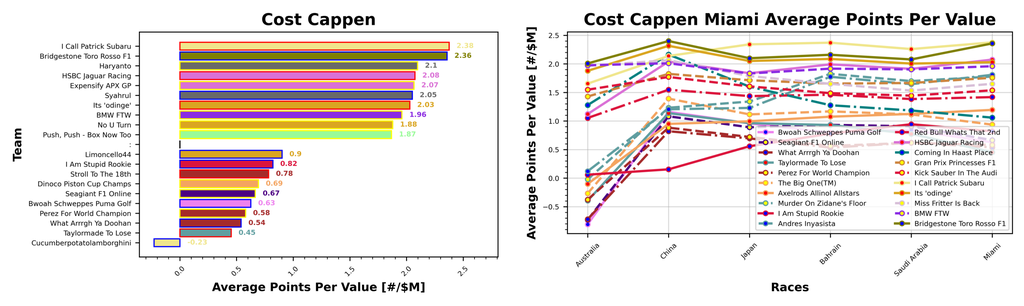

### Flavio Controls Every Millimeter

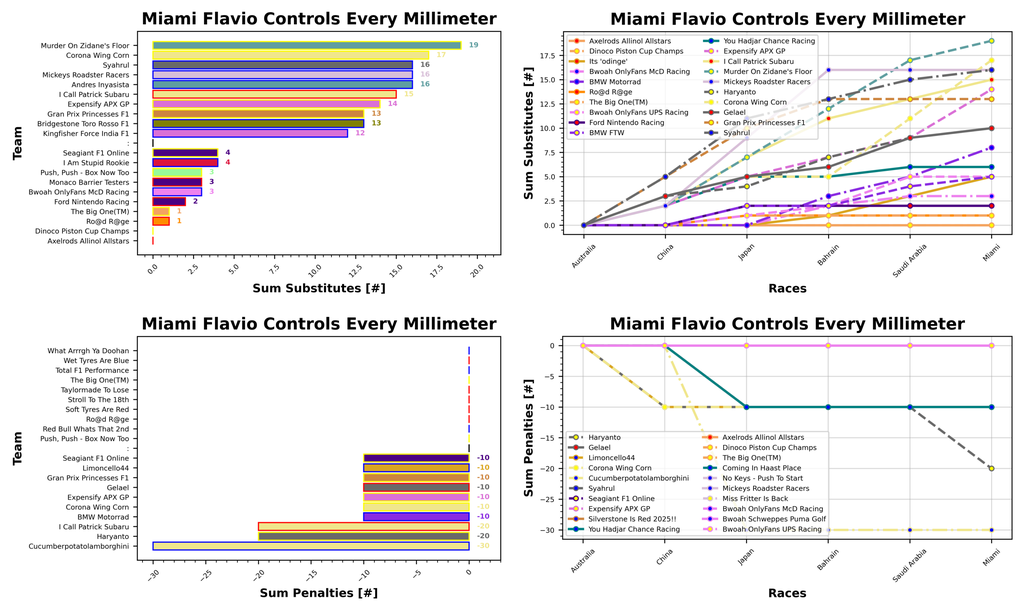

### Mega Driver

Check back later!

### Sprint King

We've finally had another sprint race, so let's see what that's done to the standings. Josh takes the lead with their other team Expensify APX GP, with 622 points. They're ahead of Sebastian and BWT Racing Point F1 who have 555 points. In third place it's Stefanus and Syahrul with 545 points.

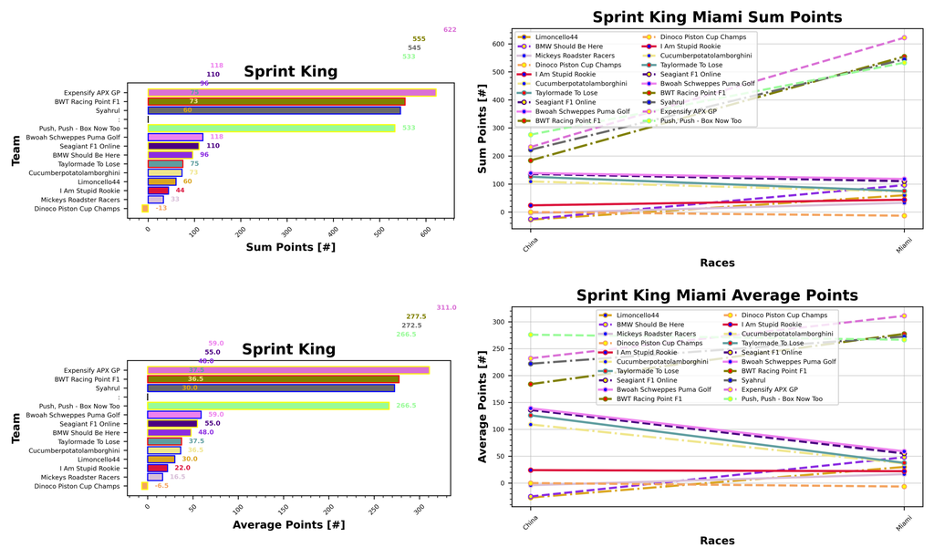

### The Continental

More To Come.

[output not shown]

### The Triple Header

More to come.

[output not shown]

### I Forgot I Was Taking Part

Similarly, I Forgot I Was Taking Part will match up with the current championship standings.

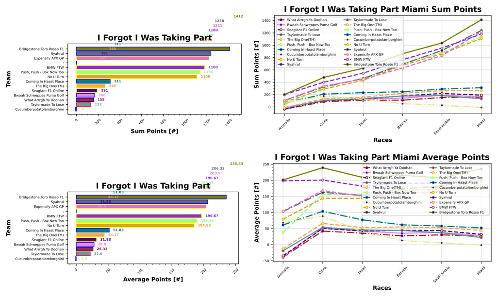

### Zak's Master Plan

Check back after the season break!

## F1 Predict

Stuart took the victory this week with 87 points, ahead of Josh with 82. Phil took third place with 47, and Val took fourth with 41. Pierce and Matty didn't participate.

This means Josh now leads the way with 327 points ahead of Stuart with 309 points. Phil is in third place with 263 points, ahead of Pierce who slips down the order to fourth with 248 points. Val is in fifth with 196, and Matty sits at the bottom with 95 points.

## Next Up

Next up, F1 travels to Italy for the Emilia Romagna Grand Prix and the first race of our second triple header. Best of luck to you all.